# model_basics

xzm

2018年3月10日

# 序

寒假那会先来没事用手机陆陆续续把Hadley大神的《[R for data science](http://r4ds.had.co.nz)》简单瞄了一遍，但有些章节只是一眼带过，有些精华不曾吸收，趁着现在一周只要开一次组会，就重新敲一敲Model章节第一部分的代码。

# 开工

大神这章以简单的线性模型为例，引入模型概念，要说简单线性模型，其实并不简单，前几天看ISLR的线性模型那章才发现有很多知识漏洞。[ISLR之线性模型](https://ditannan.me/2018/02/28/islr%E4%B9%8B%E7%BA%BF%E6%80%A7%E5%9B%9E%E5%BD%92/)

```r
library(tidyverse)
library(modelr)
library(tibble)
```

先看下`modelr`包中`sim1`数据集：

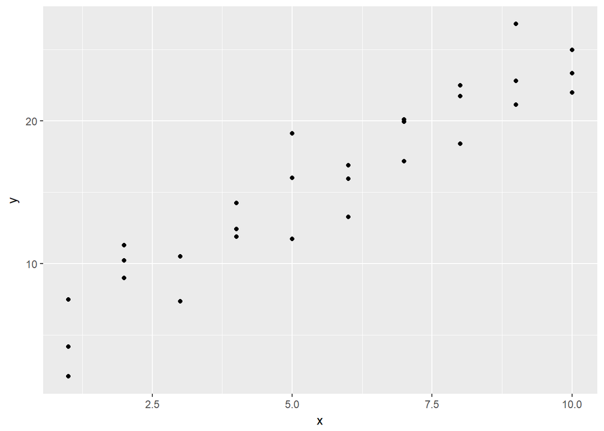

```r
sim1 %>% ggplot(aes(x, y)) +
  geom_point()
```

因此，我们试图拟合函数$y=a_0+a_1\times x$。

生成模拟的斜率和截距，并将其汇入散点图中：

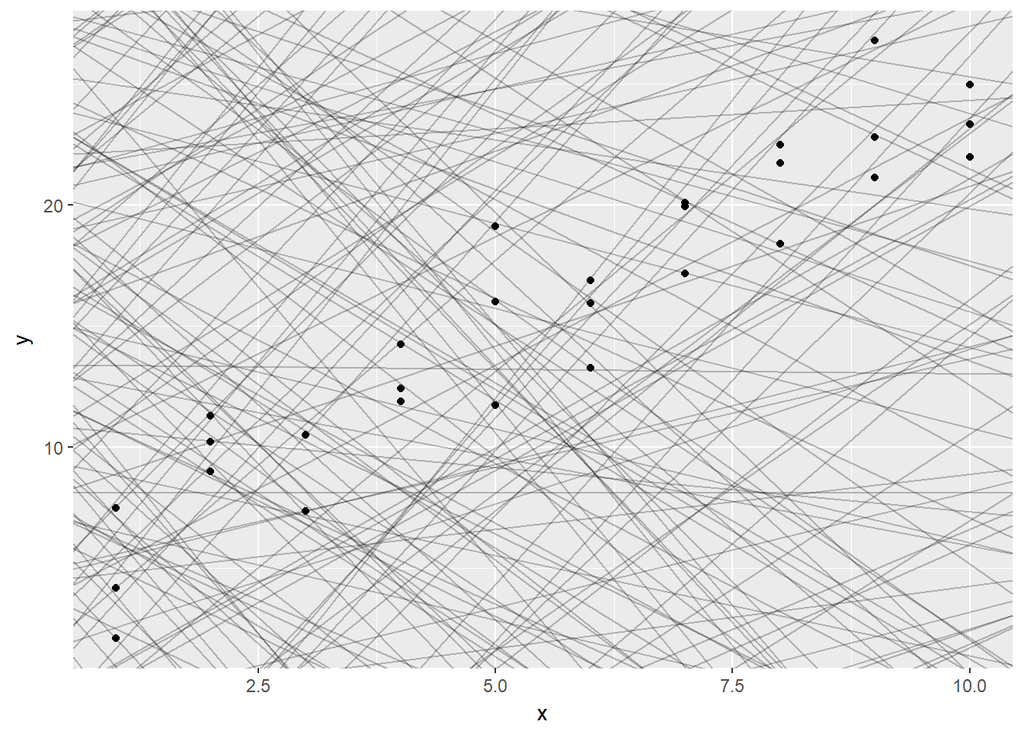

```r
models <- tibble(
  a0 = runif(250, -20, 40),
  a1 = runif(250, -5, 5)
)
sim1 %>% ggplot(aes(x, y)) +
  geom_abline(aes(intercept = a0, slope = a1), data = models, alpha = .25) +
  geom_point()
```

图中有250个模型，接下来计算哪个模型最好。根据最小二乘法，即计算$\sum(y - \bar y)^2$最小。先定义求$\bar y$函数，给定截距和斜率，计算预测函数值：

```r
model1 <- function(a, data) {
  a[1] + data$x * a[2]
}
model1(c(7, 1.5), sim1)
```

```
#>  [1]  8.5  8.5  8.5 10.0 10.0 10.0 11.5 11.5 11.5 13.0 13.0 13.0 14.5 14.5
#> [15] 14.5 16.0 16.0 16.0 17.5 17.5 17.5 19.0 19.0 19.0 20.5 20.5 20.5 22.0
#> [29] 22.0 22.0
```

当截距等于7，斜率等于1.5时得到上述预测值。 再定义求平方和函数。此处转化为求$\sqrt{\frac{(y - \bar y)^2}{n}}$

```r
measure_distance <- function(mod, data) {
  diff <- data$y - model1(mod, data)
  return(sqrt(mean(diff ^ 2)))
}
measure_distance(c(7, 1.5), sim1)
```

```
#> [1] 2.665212
```

定义求不同a0，a1对应的距离。

```r
sim1_dist <- function(a0, a1) {
  measure_distance(c(a0, a1), sim1)
}
models <- models %>%
  mutate(dist = purrr::map2_dbl(a0, a1, sim1_dist))
models
```

```
#> # A tibble: 250 x 3
#>       a0     a1  dist
#>    <dbl>  <dbl> <dbl>
#> 1   7.43 -3.89   34.1
#> 2   7.42 -0.912  15.8
#> 3  39.7   1.93   34.8
#> 4 -17.5   4.36   11.4
#> # ... with 246 more rows
```

我们再挑选出10条最好的模型，即距离最小，并上色。

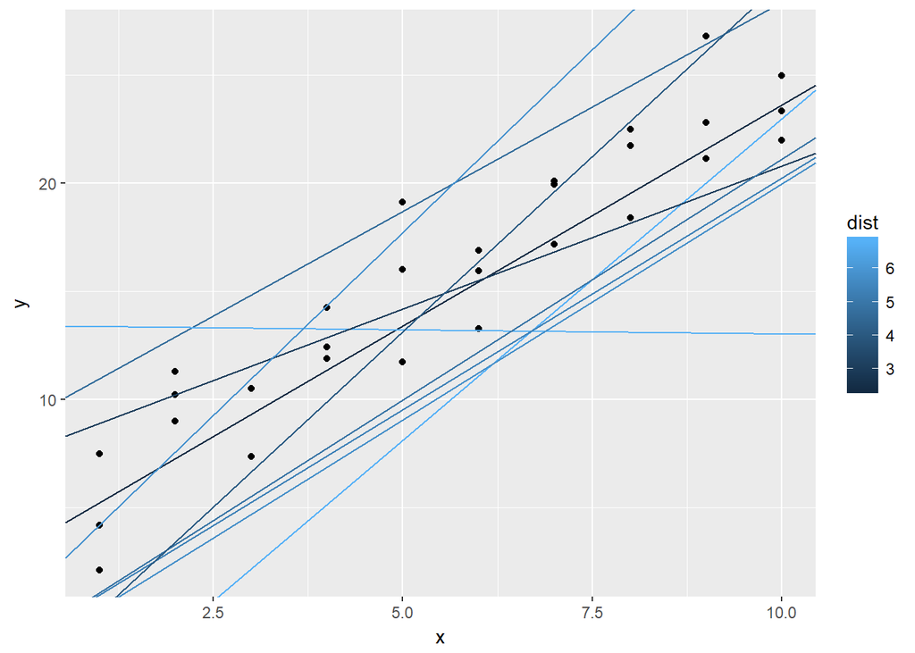

```r
sim1 %>% ggplot(aes(x, y)) +
  geom_point() +
  geom_abline(
    aes(intercept = a0, slope = a1, colour = dist),
    data = filter(models, rank(dist) <= 10)
  )
```

将这十对a0，a1在散点图中标识出来：

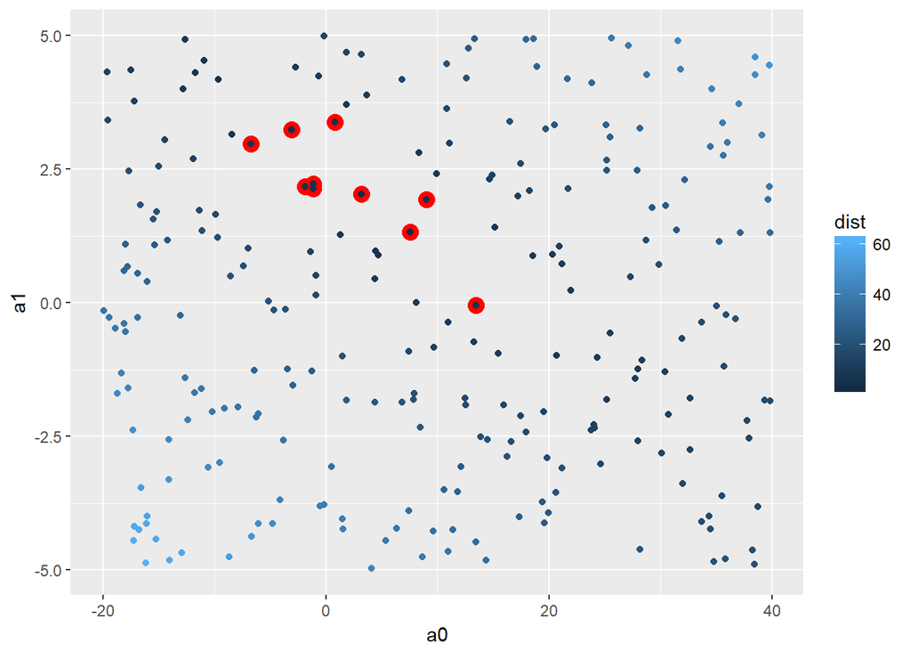

```r
models %>% ggplot(aes(a0, a1)) +
  geom_point(data = filter(models, rank(dist) <= 10), size = 4, colour = 'red') +
  geom_point(aes(colour = dist))
```

计算最优参数：

```r
best <- optim(c(0, 0), measure_distance, data = sim1)
best$par
```

```
#> [1] 4.222248 2.051204
```

将所求直线绘图

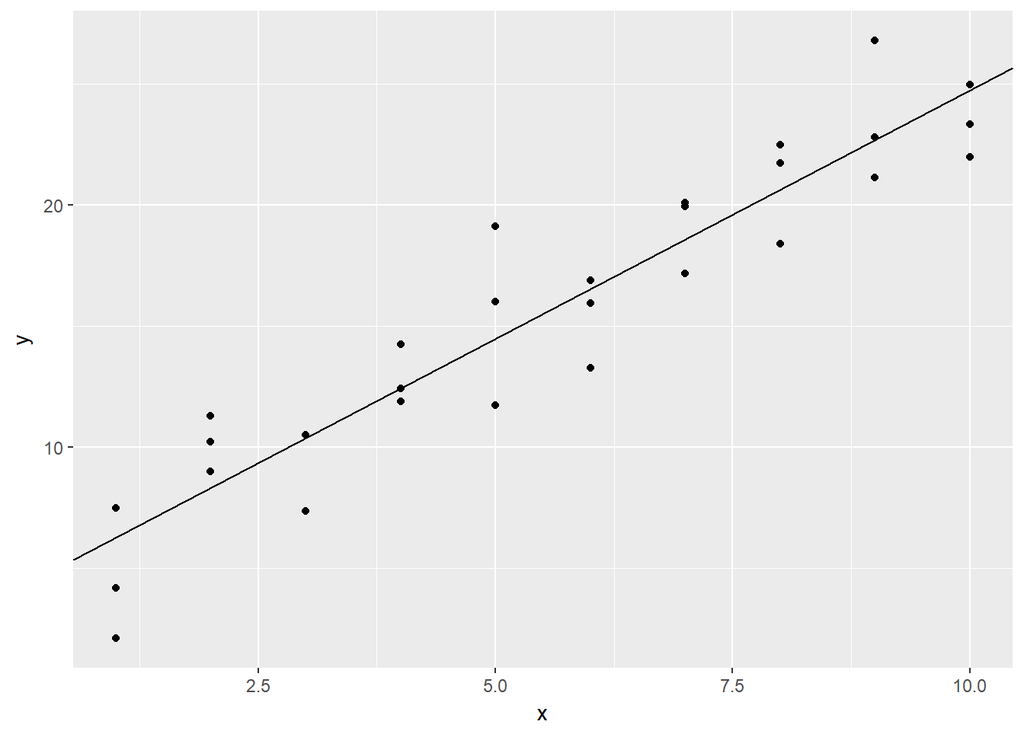

```r
sim1 %>% ggplot(aes(x, y)) +
  geom_point() +
  geom_abline(intercept = best$par[1], slope = best$par[2])
```

使用函数`lm()`计算：

```r
sim1_mod <- lm(y ~ x, data = sim1)
coef(sim1_mod)
```

```
#> (Intercept)           x
#>    4.220822    2.051533
```

# Exercise

## 1.

> One downside of the linear model is that it is sensitive to unusual values because the distance incorporates a squared term. Fit a linear model to the simulated data below, and visualise the results. Rerun a few times to generate different simulated datasets. What do you notice about the model?

```r
sim1a <- tibble(
  x = rep(1:10, each = 3),
  y = x * 1.5 + 6 + rt(length(x), df = 2)
)
```

### 生成数据集

```r
sim1a <- tibble(
  x = rep(1:10, each = 3),
  y = x * 1.5 + 6 + rt(length(x), df = 2)
)
sim1a
```

```
#> # A tibble: 30 x 2
#>       x     y
#>   <int> <dbl>
#> 1     1  7.88
#> 2     1  7.56
#> 3     1 11.1
#> 4     2 10.4
#> # ... with 26 more rows
```

看方程知道y是在x线性组合基础上加了个t分布，来个散点图看看样子：

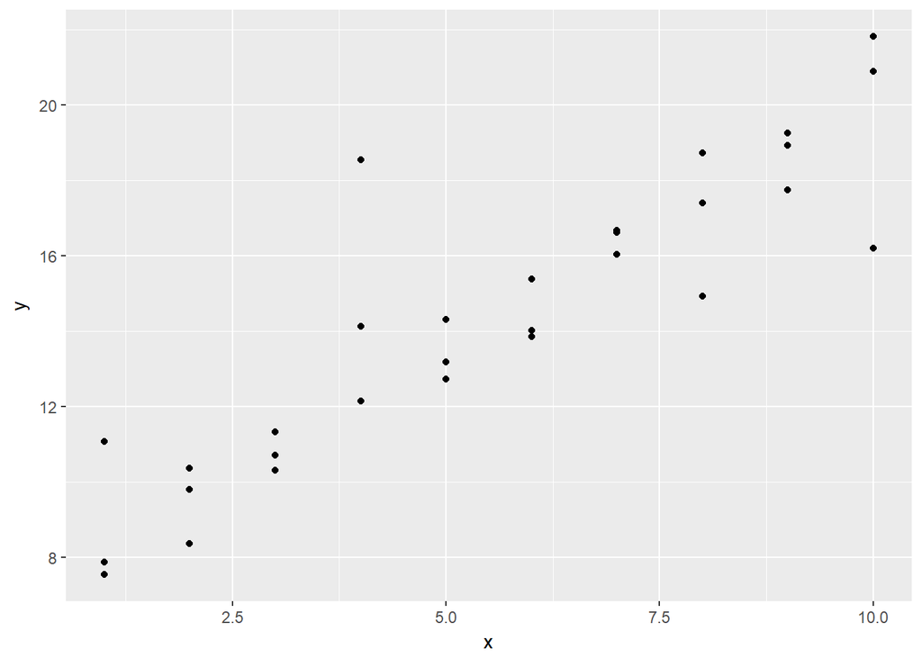

```r
sim1a_p <- sim1a %>%
  ggplot(aes(x, y)) +
  geom_point()
sim1a_p
```

拟合回归线

```r
sim1a_fit <- lm(y ~ x, data = sim1a)
coef(sim1a_fit)
```

```
#> (Intercept)           x
#>    7.771845    1.198655
```

将直线添加到图形中

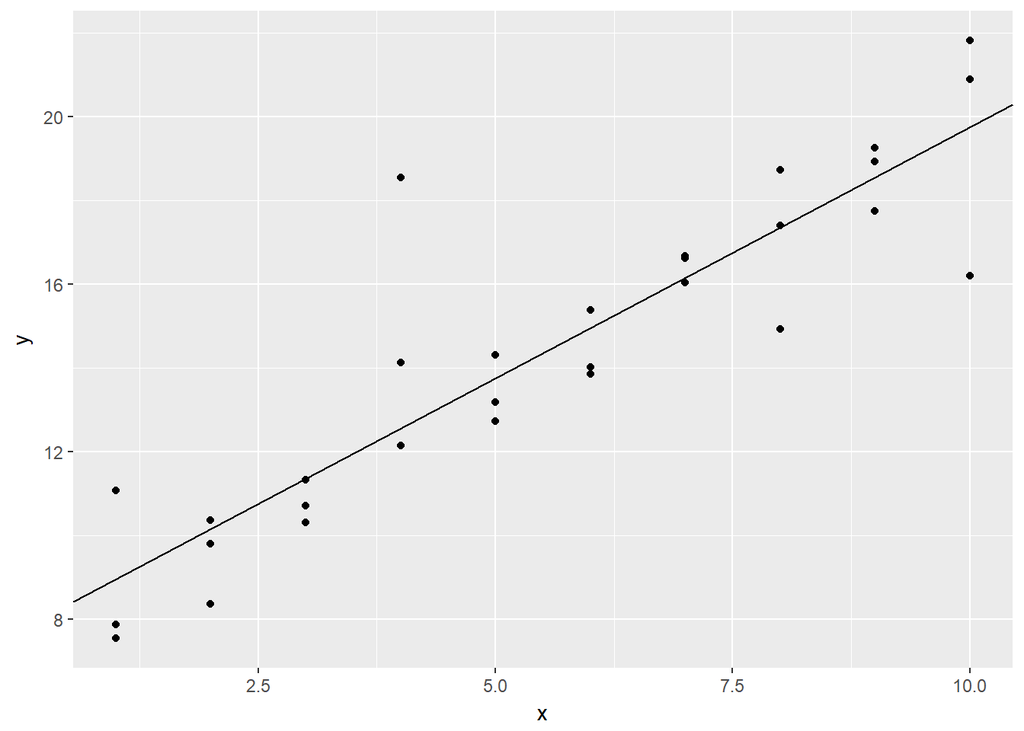

```r
sim1a_p + geom_abline(intercept = coef(sim1a_fit)[1], slope = coef(sim1a_fit)[2])
```

大神让我们多重复几次，会有新发现，发现就是总是有个点是异常值，模型变化也很大，说明模型很容易受异常值的影响。

这样吧，我们试着拟合个50次，看看每次的截距和斜率是怎样的变化。

```r
par <- matrix(0, nrow = 50, ncol = 2)
for(i in 1 : 50) {
  sim1a <- tibble(
    x = rep(1:10, each = 3),
    y = x * 1.5 + 6 + rt(length(x), df = 2)
  )
  sim1a_fit <- lm(y ~ x, data = sim1a)
  par[i, 1] <- coef(sim1a_fit)[1]
  par[i, 2] <- coef(sim1a_fit)[2]
}
par
```

```
#>           [,1]     [,2]
#>  [1,] 7.208397 1.293467
#>  [2,] 6.061099 1.521352
#>  [3,] 6.169455 1.421165
#>  [4,] 6.662024 1.329275
#>  [5,] 6.462771 1.446051
#>  [6,] 6.306484 1.477598
#>  [7,] 5.658636 1.529139
#>  [8,] 5.611372 1.380011
#>  [9,] 5.238113 1.635378
#> [10,] 7.637606 1.395154
#> [11,] 6.678085 1.485388
#> [12,] 6.202115 1.421129
#> [13,] 4.359015 1.681410
#> [14,] 5.939519 1.543237
```

[output cut: 36 more lines]

看看截距的变异sd=sd(par[, 1])= 0.8739323,看看斜率的变异sd=sd(par[, 2])= 0.1340779。还是有些不同的。

```r
summary(par[, 1])
```

```
#>    Min. 1st Qu.  Median    Mean 3rd Qu.    Max.
#>   4.359   5.700   6.254   6.300   6.853   9.156
```

```r
summary(par[, 2])
```

```
#>    Min. 1st Qu.  Median    Mean 3rd Qu.    Max.
#>   1.163   1.360   1.480   1.475   1.593   1.746
```

## 2.

> One way to make linear models more robust is to use a different distance measure. For example, instead of root-mean-squared distance, you could use mean-absolute distance:

```r
measure_distance <- function(mod, data) {
  diff <- data$y - make_prediction(mod, data)
  mean(abs(diff))
}
```

> Use optim() to fit this model to the simulated data above and compare it to the linear model.

那我们就使用optim()函数求解使用均数绝对值的距离拟合数据的最佳模型：

```r
make_prediction <- function(mod, data) {
  mod[1] + mod[2] * data$x
}
measure_distance <- function(mod, data) {
  diff <- data$y - make_prediction(mod, data)
  mean(abs(diff))
}
best <- optim(c(0, 0), measure_distance, data = sim1)
best$par
```

```
#> [1] 4.364852 2.048918
```

上面我们用`lm()`得到的模型系数是 4.2208219, 2.0515331。